# matriz

MATOPIBA

O Brasil exemplifica um país onde se há grandes desequilíbrios regionais. E são essas disparidades regionais, em suas mais diversas escalas (regiões, estados, municípios, micro e mesorregiões) que tem se tornado objeto de preocupação e estudo tanto para acadêmicos quanto para gestores públicos. Essa preocupação , segundo Wiltgen decorre não apenas do aspecto de justiça social, mas também da eficiência global do sistema econômico. (Wiltgen, 1991)

Apesar de muito estudado, o problema permanece sem solução adequada. O Brasil continua a ser um país marcado por grandes desigualdades regionais, e essa disparidade é reconhecida pelo BNDES por certas linhas de financiamento que concedem incentivos a projetos especialmente nas regiões Norte, Nordeste e Centro-Oeste do país.

A Organização das Nações Unidas (ONU) criou o IDH com o intuito de obter uma fórmula mais abrangente para medir o nível de desenvolvimento e o bem-estar das diferentes populações. Entre os indicadores internacionais de desenvolvimento, o IDH é o mais aceito

Fazendo uma classificação, baseada no IDH das regiões brasileiras, teremos a seguinte hierarquia:

Primeiro lugar: Rio Grande do Sul, Santa Catarina, São Paulo, Paraná, Rio de Janeiro, Espírito Santo e Mato Grosso do Sul; Segundo lugar: Minas Gerais, Goiás, Mato Grosso, Rondônia, Amazonas, Roraima e Amapá; Terceiro lugar: Acre, Pará e Sergipe. Por último, estão os estados do Nordeste, com exceção de Sergipe.

O país é um dos grandes produtores agrícolas do mundo. Estudos chegam a estimar que a produção brasileiro alimente 800 milhões de pessoas em todo o mundo (CONTINI, 2021). Em contrapartida, a insegurança alimentar faz parte da rotina de mais da metade dos brasileiros, 116,8 milhões de pessoas. A insegurança alimentar grave afeta 9% da população, ou seja, 19,1 milhões de brasileiros estão passando fome. Dos lares em insegurança alimentar grave 31,9% se encontram na região norte e nordeste do país. (Rede PENSSAN, 2021).

1. Foram incentivados por políticas e programas governamentais (Silva et al., 2015) voltados ao desenvolvimento de novas áreas no Cerrado do Norte e Nordeste do Brasil, como o Programa de Desenvolvimento do Cerrado [Polocentro], Programa de Terras e de Estímulo à Agroindústria do Norte e do Nordeste [Polonordeste] e o Programa de Cooperação Nipo-Brasileira de Desenvolvimento Agrícola da Região do Cerrado [Prodecer]. Estes ofereceram benefícios a produtores, como crédito agrícola e menor preço para compra de terra, para a exploração agrícola na região do Cerrado dos estados do Maranhão, Tocantins, Piauí e Bahia (Matos e Pessôa, 2011; Alves, 2014; Barbosa et al., 2015).

Desde a chegada desses produtores, foi sendo estabelecida uma cultura empreendedora no campo, com a aplicação de alta tecnologia em insumos e maquinários, investimentos em abertura de áreas, correção de solo e irrigação.

O resultado desse investimento somado a experiência dos produtores, resultou em uma das regiões de maior destaque na produção agrícola atual do Brasil, principalmente nas culturas de soja, milho e algodão (Branco et al., 2010; Branco e Caixeta Filho, 2011).

Devido ao alto grau de investimentos e a abertura de novas áreas, a região apresentou um crescimento na produção de grãos de 20% ao ano, contra a média nacional de 3,5% ao ano. Destaca-se o crescimento dos municípios ligados ao agronegócio presentes na região do MATOPIBA em relação aos municípios de outras regiões e diferentes setores.

Com o grande crescimento agrícola e econômico da região e a necessidade de investimentos para continuar se desenvolvendo, fez-se necessária sua delimitação territorial por parte do Governo Federal.

# DELIMITAÇÃO TERRITORIAL

A delimitação geográfica do MATOPIBA aconteceu através de um acordo entre o Ministério do Desenvolvimento agrário (MDI), Instituto Nacional de Colonização e Reforma Agrária (INCRA) e do Grupo de Inteligência Territorial Estratégica (GITE) juntamente com a Empresa Brasileira de Pesquisa Agropecuária (EMBRAPA) (MIRANDA; MAGALHÃES; CARVALHO, 2014).

Por meio do Decreto Nº 8447, de 6 de maio de 2015 expressa a finalidade de promover e coordenar políticas públicas direcionadas ao desenvolvimento econômico sustentável fundado nas atividades agrícolas e pecuárias que provenham na melhoria da qualidade de vida da população (XAVIER, 2019). Mondardo e Azevedo (2019, p.305) exploram as diretrizes do decreto Nº 8447, de 6 de maio de 2015:

I - Desenvolvimento e aumento da eficiência da infraestrutura logística relativa às atividades agrícolas e pecuárias;

II - Apoio à inovação e ao desenvolvimento tecnológico voltados às atividades agrícolas e pecuárias; e

III - Ampliação e fortalecimento da classe média no setor rural, por meio da implementação de instrumentos de mobilidade social que promovam a melhoria da renda, do emprego e da qualificação profissional de produtores rurais.

A delimitação do MATOPIBA não abrange a totalidade dos Estados da Bahia, Maranhão e Piauí, apenas algumas áreas desses três Estados foram selecionadas para fazerem parte do projeto MATOPIBA, exceto o Tocantins, que é totalmente coberto pelo projeto.

Segundo De Miranda et al. (2014), a região do MATOPIBA está distribuída entre os quatro Estados da seguinte maneira:

[figure not shown]

# CRITÉRIOS PARA DELIMITAÇÃO TERRITORIAL

O primeiro critério para delimitação geográfica do espaço foi as áreas existentes de cerrado nos Estados do Maranhão, Piauí, Tocantins e Bahia. Sendo qualificada a partir de imagens de satélite e a dinâmica de uso e ocupação dessas terras. O segundo critério foi a dimensão socioeconômica, principalmente no relativo à produção agropecuária e florestal das pesquisas anuais do Instituto Brasileiro de Geografia e Estatística - IBGE.

# CARACTERISTICAS DEMOGRAFICAS

# POPULAÇÃO

A população de MATOPIBA é estimada em 5,9 milhões de pessoas o que representa 3,1% da população nacional.

Sua densidade demográfica é de 13,4 habitantes por km² e sua população rural é de 2 milhões de pessoas resultando em uma taxa de urbanização de 65%. Essa taxa de urbanização em MATOPIBA está ligada não somente a migração rural mas também ao fluxo migratório de outras regiões brasileiras.

A nível de comparação a taxa de urbanização nacional é de 84% e a densidade demográfica é de 22,4 hab/km²

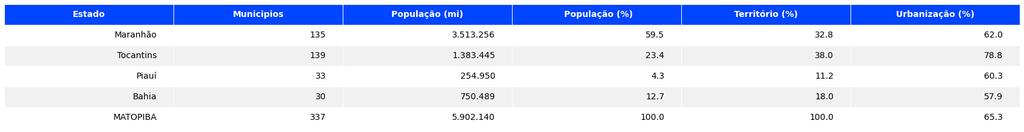

# CARACTERISTICAS ECONOMICAS

# CONTRIBUIÇÃO POR SETORES

Entre 2010 e 2015, o MATOPIBA apresentou uma taxa de crescimento do PIB real de 5,1% a.a., bem superior à taxa de crescimento brasileira de 1,5% a.a

# PIB MATOPIBA: CONTRIBUIÇÃO POR ESTADO

Ainda que o estado de Tocantins apresente o maior número de municípios do MATOPIBA, o estado do Maranhão, em 2015, era o que apresentava a maior participação no PIB total da região, com 44,5%, seguido por Tocantins com 30,8%. Piauí, por outro lado, é o menor em termos de representatividade do PIB regional, contribuindo com apenas 3,4%, e a Bahia, que apresenta a menor quantidade de municípios, responde por 21,3% do PIB regional.

# CRESCIMENTO ECONÔMICO

Nos últimos 20 anos, observou-se grande aumento na produção de soja resultante do crescimento da área plantada e da produtividade em MATOPIBA. A consequência direta desse processo foi o aumento do PIB dos municípios que constituem a região. No entanto, há concentração da riqueza gerada no MATOPIBA, uma vez que grande parcela da população das cidades localizadas nessa região está à margem dos benefícios gerados pelo agronegócio.

Sá et al. (2015) argumentam que ainda que embora MATOPIBA venha experimentando uma onda de crescimento econômico, desencadeada principalmente pelo aumento da produtividade dos fatores associados ao agronegócio, isso não tem sido revertido em desenvolvimento. Uma das razões para dar suporte a essa argumentação é que o uso da mão de obra local é limitado, o que exclui grande parcela da população residente. Mais que isso, o modelo agrícola moderno prioriza o uso de insumos químicos e bens de capital (recursos escassos) na agropecuária em detrimento da mão de obra. Todavia, o recurso abundante e barato no Brasil é justamente a mão de obra (pouco qualificada), que acaba marginalizada.

A Embrapa identificou que das 250 mil fazendas localizadas no MATOPIBA registradas no Censo Agropecuário de 2006 do IBGE, 94% dessas unidades têm como proprietários pessoas pobres (14%) ou muito pobres (80%), conforme mostra a tabela abaixo.

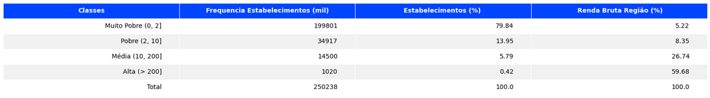

A classe muito pobre recebe até 2 salários mínimos mensais, ao passo que a classe pobre recebe entre 2 e 10 salários mínimos. Por outro lado, a classe média recebe entre 10 e 200 salários mínimos e a mais rica ganha acima de 200 salários mínimos. Percebe-se que apenas 0,42% dos estabelecimentos concentram cerca de 60% da renda bruta total da região do MATOPIBA (Alves et al., 2015).

# PRINCIPAIS PRODUTOS

Inicialmente, a região foi povoada por pequenos agricultores e grandes pecuaristas, mas o padrão de uso da terra mudou rapidamente na última década. A maioria do cultivo recente de terras em MATOPIBA ocorreu através de operações altamente mecanizadas e eficientes – em forte contraste com o histórico de outras fronteiras agrícolas brasileiras. Nos últimos dez anos, MATOPIBA passou a responder por quase 10% da produção de grãos do país, e os seus três produtos principais – soja, milho e algodão – no mínimo dobraram sua produção nesse período. Além disso, as áreas de pastagem em MATOPIBA têm diminuído continuamente desde 1980, em termos absolutos e em participação relativa da área rural.

# PRINCIPAIS MUNICIPIOS EXPORTADORES

*As grandes áreas latifundiária do MATOPIBA podem ser observadas por imagens de satélite.*

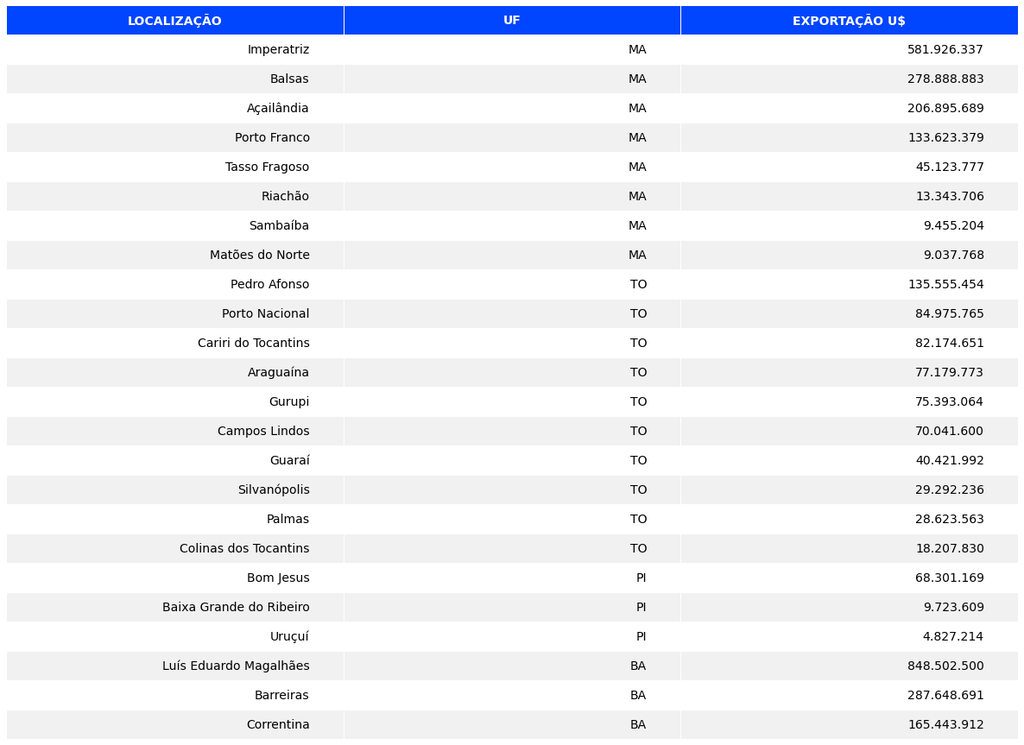

[interactive chart not shown]

# SOJA

A soja, é o principal produto do MATOPIBA.

No tocante à área ocupada pela cultura da soja, conforme análise geoespacial que resultou em relatório síntese organizado por Rudorff, B.; Risso, J. et al (2015) e pela Agrosatélite Geotecnologia Aplicada Ltda., houve um expressivo aumento no intervalo 2006/07-2013/14.

# ESCOAMENTO PRODUÇÃO MATOPIBA

Dos grandes desafios das novas fronteiras agrícolas, o referente a infraestrutura logistica disponível em cada região para o escoamento da safra é um dos principais.

As chuvas intensas que atingem a região levam os produtores rurais da região a colocar máquinas e tratores nas estradas, principalmente na TransCerrado.

Diante da falta de investimentos na principal rodovia de escoamento da produção agrícola, os caminhões carregados com a soja não conseguem transitar.

Em MATOPIBA um dos investimentos para minimizar o problema foi a criação de novas rotas ferroviárias que ligam as regiões produtoras aos portos do Nordeste. A principla ferrovia instalada é a Ferrovia Norte Sul, administrada pela empresa Valor da Logistica Integrada [ VLI ], que conta com 720 km de extensão em operação, ligando os municípios de Porto Nacional, Tocantins à Açailândia, Maranhão, integrando-se à ferrovia Estrada de Ferro Carajás, com destino ao Porto de Itaqui, em São Luís, Maranhão, seu ponto final, aonde a soja é armazenada e carregada em navios para exportação.

[interactive chart not shown]

A soja produzida no MATOPIBA é destinada principalmente para a produção de óleo vegetal, biodiesel e priciplamente o mercado externo.

Hoje, há duas rotas principais utilizadas no escoamento e exportação de soja no MATOPIBA. A primeira atende o Oeste da Bahia, o Sudeste do Tocantins e o Sul do Piauí, onde o grão é transportado até o porto de Salvador e em menores proporções ao porto de Ilhéus. A segunda rota é voltada ao Centro e Norte do Tocantins e Piauí e todo o Maranhão, onde a soja é transportada até o porto de Itaqui, em São Luís, Maranhão.

No escoamento da soja para os portos da Bahia é utilizado, predominantemente, o modal rodoviário pela BR-242, que liga o interior ao litoral do estado. A soja com destino ao porto de Itaqui - MA conta com rotas rodoviárias, pelas BR-230, BR-135 e BR-235 no Piauí e Leste do Maranhão e rotas ferroviárias, pela Ferrovia Norte-Sul, por meio dos terminais de Porto Nacional e Palmeirante no Tocantins e de Porto Franco, no Oeste do Maranhão (CNT, 2015).

# CARACTERISTICAS AMBIENTAIS

A área que corresponde ao território do Matopiba abrange quatro regiões hidrográficas, são elas: Tocantins-Araguaia; Parnaíba; Atlântico Nordeste Ocidental; São Francisco.

De acordo com estudo da Agrosatélite*, a agricultura anual do Cerrado é composta principalmente por SOJA, ALGODÃO e MILHO.

A soja é a cultura que predomina no Cerrado, ocupando uma área de 15,6 milhões de ha, que representa 90% da agricultura anual. Aproximadamente, 52% de toda a soja do Brasil está no bioma Cerrado.

As áreas de milho primeira safra e algodão somados ocupam uma área de 1,7 milhões de ha, 10% da agricultura anual. Mesmo sendo uma área pequena em consideração à área de soja, metade da área de algodão de todo o Brasil está no Cerrado.